# Analysis of skink dataset

```r
library(monitoR)
pacman::p_load(conflicted, tidyverse, gt)
theme_set(theme_bw())
```

# Data

```r
data(skink)
```

```r
skink |> glimpse()
```

```
#> Rows: 6,728
#> Columns: 4
#> $ time      <dttm> 2024-03-25 14:34:01, 2024-03-25 14:35:01, 2024-03-25 14:36:…
#> $ X         <dbl> 229, 248, 235, 250, 252, 248, 255, 256, 190, 141, 250, 261, …
#> $ Y         <dbl> 213, 200, 221, 207, 214, 215, 275, 283, 370, 401, 243, 231, …
#> $ behaviour <chr> "Basking", "Basking", "Basking", "Movement", "Basking", "Bas…
```

# Processing

First we add a 4x4 grid

```r
grid <- create_grid(range(skink$X), range(skink$Y), dim = c(4,4))
skink_grid <- skink |> add_grid(grid)
```

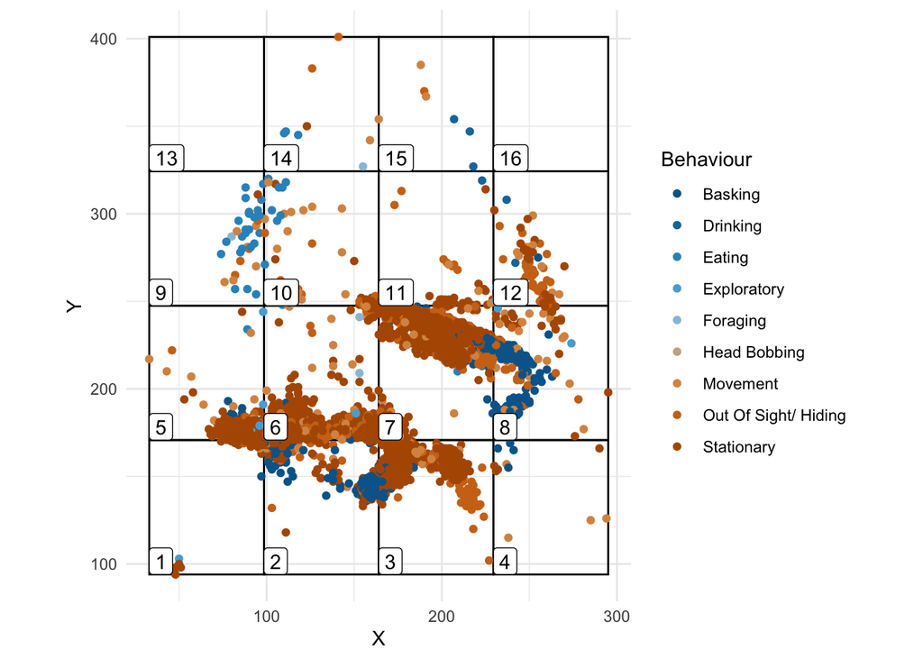

Figure 1: Skink dataset with grid

```r
plot_grid(grid, skink_grid)
```

# Index measures

## Entropy

First we look at the entropy of observation for the data given in Figure 1.

```r
calc_entropy(skink_grid$grid)
```

```
#> [1] 0.7944013
```

**Q1: Is it evenly spread?** We know that the entopy for evenly spread data over a 4x4 grid using log<sub>10</sub> is

log<sub>10</sub>(16)

```r
log10(16)
```

```
#> [1] 1.20412
```

In our case, we have 0.7944013 which is smaller indicating non-even spread. We may wonder if this is significant?

To test this, we will create a empirical null distribution based on simulating data with equal spread of grids

```r
null_entropy <- monitoR::get_entropy_null(skink_grid$grid, n_sims = 1000, n_grid = 16)
```

If we look at the 95% percentiles

```r
quantile(null_entropy, c(0.025, 0.975))
```

```
#>     2.5%    97.5%
#> 1.203210 1.203921
```

we see that it does not contain the observed value, so the observations are not evenly spread.

**Entropy and behaviour**

Next, we will calculate the entropy for each behaviour (Figure 2). In this we see a difference in entropy for different behaviours. For example, the most evenly spread is movement, while foraging is the least spread.

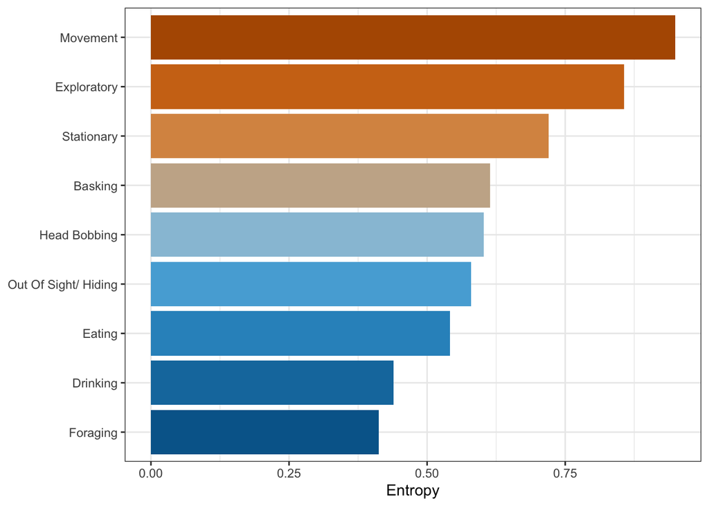

Figure 2: Entropy for each behaviour

```r
skink_grid |>
  summarise(entropy = calc_entropy(grid), .by = behaviour) |>
  mutate(
    behaviour = fct_reorder(behaviour, entropy)
  ) |>
  ggplot(aes(entropy, behaviour, fill = behaviour)) +
  geom_col(show.legend = FALSE) +
  harrypotter::scale_fill_hp_d("Ravenclaw") +
  labs(x = "Entropy", y = NULL)
```

To assess the difference between the entropy for the different behaviours, we will used the squared distance of each entropy from the overall entropy

$$ESS = \sum^k_{i = 1} (E_i - E_{\bullet})^2,$$

where *E*<sub>*i*</sub> is the entropy for the *i*th behaviour, and *E*<sub>•</sub> is the entropy for all observations.

For Figure 2, we have

```r
get_ess(skink_grid)
```

```
#> [1] 0.4849358
```

As before, the question is

> Is this significant?

To access this, we will use a permutation test, so we will

- Permute the grid recorded in the data
- Calculate ESS each time

```r
ess_null <- get_ess_null(skink_grid, n_sims = 100)
quantile(ess_null, c(0.025, 0.975))
```

```
#>      2.5%     97.5%
#> 0.1576487 0.8421979
```

So this time we find that the observed ESS is within the 95% empirical confidence interval and so is not surprising.

# Environment effects

So, we will now focus on Basking (Figure 3). We will assume for illustration that there are rocks in Grid 5, 6, 7, 8, 2, and 3.

We want to ask the question of

> Is it more likely to bask where there are rocks?

```r
skink_bask <- skink_grid |>
  filter(behaviour == "Basking")
```

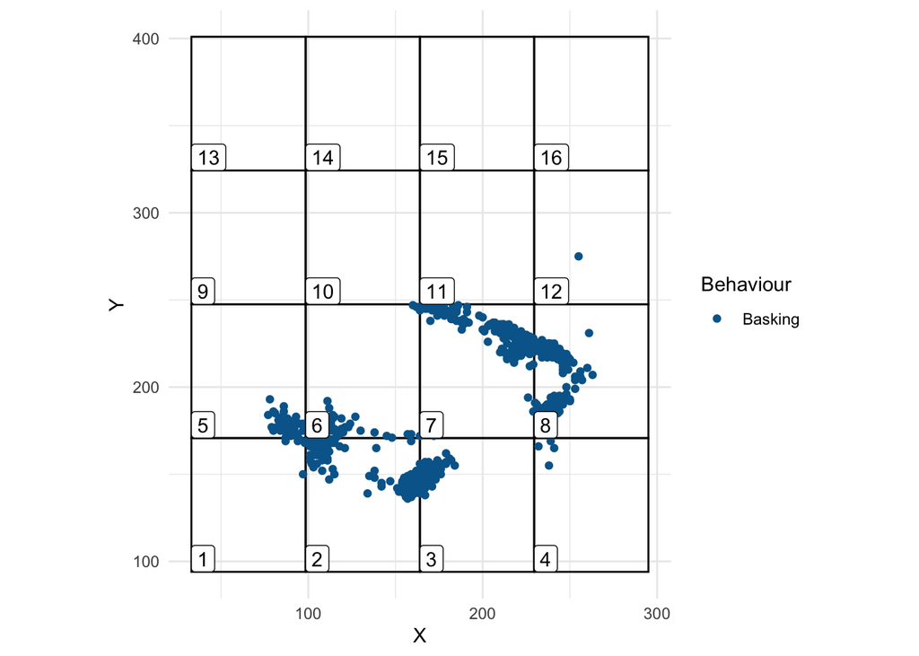

Figure 3: Observations where just basking

```r
plot_grid(grid, skink_bask)
```

Table 1 gives the number of times that the skink is seen basking in each grid. As well, we have given the type of environment.

```r
basking_df <- count_grid_behaviour(grid = grid, skink_bask)
basking_df <- basking_df |>
  mutate(
    environ = "normal"
  )
basking_df$environ[c(2, 3, 5, 6, 7, 8)] <- "rocks"
basking_df |> gt()
```

Table 1: Count of number of basking events for each grid.

| grid | obs | environ |
| --- | --- | --- |
| 1 | 5 | normal |
| 2 | 684 | rocks |
| 3 | 126 | rocks |
| 4 | 4 | normal |
| 5 | 36 | rocks |
| 6 | 47 | rocks |
| 7 | 199 | rocks |
| 8 | 166 | rocks |
| 9 | 0 | normal |
| 10 | 0 | normal |
| 11 | 7 | normal |
| 12 | 1 | normal |
| 13 | 0 | normal |
| 14 | 0 | normal |
| 15 | 0 | normal |
| 16 | 0 | normal |

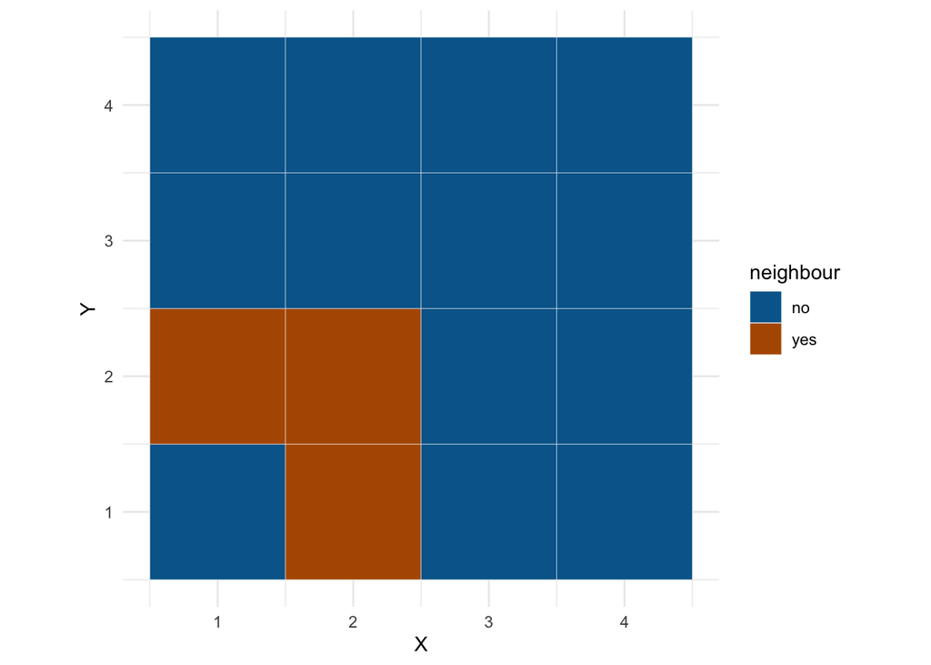

Figure 4: Neighbourhoods.

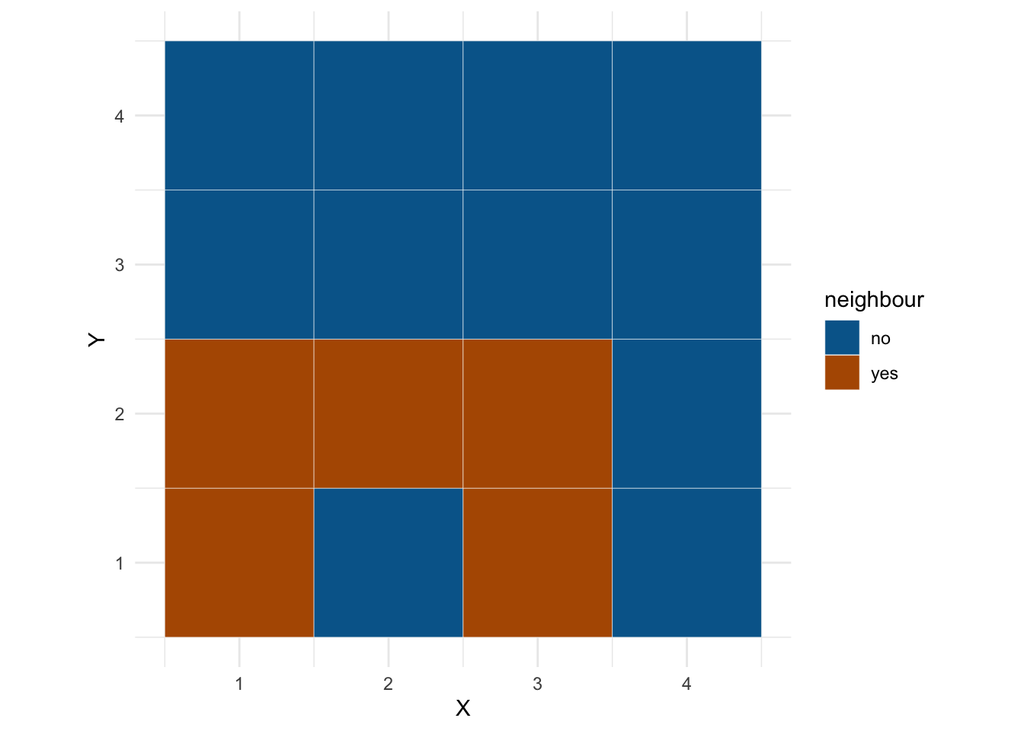

Figure 5: Neighbourhoods.

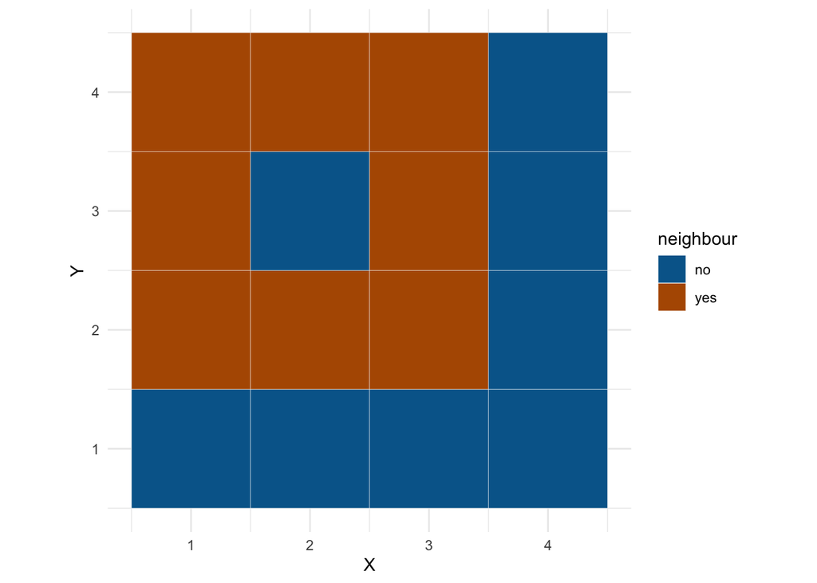

Figure 6: Neighbourhoods.

```r
plot_neigh(grid, 1)
plot_neigh(grid, 2)
plot_neigh(grid, 10)
```

First we add the neigh mean.

```r
M <- get_neigh_mat(grid)
basking_df$neigh <- as.numeric(M %*% basking_df$obs)
basking_df
```

```
#> # A tibble: 16 × 4
#>     grid   obs environ  neigh
#>    <dbl> <dbl> <chr>    <dbl>
#>  1     1     5 normal  256.
#>  2     2   684 rocks    82.6
#>  3     3   126 rocks   220
#>  4     4     4 normal  164.
#>  5     5    36 rocks   147.
#>  6     6    47 rocks   132.
#>  7     7   199 rocks   129.
#>  8     8   166 rocks    67.4
#>  9     9     0 normal   16.6
#> 10    10     0 normal   36.1
#> 11    11     7 normal   51.6
#> 12    12     1 normal   74.4
#> 13    13     0 normal    0
#> 14    14     0 normal    1.4
#> 15    15     0 normal    1.6
#> 16    16     0 normal    2.67
```

And then fit some models

```r
M1 <- lm(obs ~ environ * neigh, data = basking_df)
summary(M1)
```

```
#>
#> Call:
#> lm(formula = obs ~ environ * neigh, data = basking_df)
#>
#> Residuals:
#>     Min      1Q  Median      3Q     Max
#> -174.75   -3.78   -0.61   -0.30  375.19
#>
#> Coefficients:
#>                    Estimate Std. Error t value Pr(>|t|)
#> (Intercept)          0.4625    54.1866   0.009   0.9933
#> environrocks       481.9039   167.0120   2.885   0.0137 *
#> neigh                0.0205     0.5367   0.038   0.9702
#> environrocks:neigh  -2.1217     1.2582  -1.686   0.1175
#> ---
#> Signif. codes:  0 '***' 0.001 '**' 0.01 '*' 0.05 '.' 0.1 ' ' 1
#>
#> Residual standard error: 137.3 on 12 degrees of freedom
#> Multiple R-squared:  0.5002, Adjusted R-squared:  0.3752
#> F-statistic: 4.003 on 3 and 12 DF,  p-value: 0.03452
```

```r
M2 <- update(M1, .~. - environ:neigh)
summary(M2)
```

```
#>
#> Call:
#> lm(formula = obs ~ environ + neigh, data = basking_df)
#>
#> Residuals:
#>     Min      1Q  Median      3Q     Max
#> -167.30  -30.50  -20.25    2.68  457.09
#>
#> Coefficients:
#>              Estimate Std. Error t value Pr(>|t|)
#> (Intercept)   23.7684    55.9865   0.425   0.6781
#> environrocks 233.3370    83.9025   2.781   0.0156 *
#> neigh         -0.3655     0.5187  -0.705   0.4934
#> ---
#> Signif. codes:  0 '***' 0.001 '**' 0.01 '*' 0.05 '.' 0.1 ' ' 1
#>
#> Residual standard error: 146.8 on 13 degrees of freedom
#> Multiple R-squared:  0.3817, Adjusted R-squared:  0.2866
#> F-statistic: 4.013 on 2 and 13 DF,  p-value: 0.04391
```

```r
M3 <- update(M2, .~. - neigh)
summary(M3)
```

```
#>
#> Call:
#> lm(formula = obs ~ environ, data = basking_df)
#>
#> Residuals:
#>     Min      1Q  Median      3Q     Max
#> -173.67  -18.92   -1.70    0.05  474.33
#>
#> Coefficients:
#>              Estimate Std. Error t value Pr(>|t|)
#> (Intercept)      1.70      45.57   0.037   0.9708
#> environrocks   207.97      74.41   2.795   0.0143 *
#> ---
#> Signif. codes:  0 '***' 0.001 '**' 0.01 '*' 0.05 '.' 0.1 ' ' 1
#>
#> Residual standard error: 144.1 on 14 degrees of freedom
#> Multiple R-squared:  0.3581, Adjusted R-squared:  0.3123
#> F-statistic: 7.811 on 1 and 14 DF,  p-value: 0.01433
```

So it looks like there is no dependency.